# Your Digest for Tuesday, Aug 01, 2023 11:59 PM

## Pathology of psoriatic lesions

Epidermal hyperplasia + other changes;  
Parakeratosis - persistence of nuclei in stratum corneum.

[figure not shown]

## Auspitz sign

Another classic psign of chronic plaque psoriasis: visualization of pinpoint bleeding after removal of scale overlying a psoriatic plaque.

## Triggers for psoriasis:

There are 5 types of join inveoment in psoriasis - [[General medicine 2#1 Psoriatic arthritis (PsA)|Psoriatic arthritis]]

- *Commonest is asymmetrical oligoarthritis*

### Subtypes of psoriasis

[figure not shown]

#### Chronic plaque psoriasis

Thick Silvery scale  
Symmetrical,  
Typical areas: Scalp, extensor elbows, knee, gluteal cleft; Inverse psoriasis -> involvement of *intertriginous* (skin coming into contact with itself) areas.  
Post inflammatory hyperpigmentation +  
**Pruritus is common**

#### Guttate psoriasis

**abrupt** appearance of multiple small papules and plaques.  
Areas: Trunk and proximal extremities  
Epid: Usually occurs in a **child or young adult** with no previous history of psoriasis; strongly associated with recent *streptococcal* infection. (usually pharyngitis).

#### Pustular psoriasis

**Can be life threatening**  
Causes: pregnancy, infection, withdrawal of oral glucocorticoids.  
(most severe from **Von-Zumbusch** - generalized pustular psoriasis)  
**Acute onset, widespread erythema**.  
Fever, leukocytosis, **hypocalcemia**.  
Possibly complicated by sepsis and renal / hepatic involvement.  
*Pustular psoriasis of pregnancy*: are form, usually occuring during T3 of pregnancy.

#### Erythrodermic psoriasis

Uncommon;  
Erythrodermic psoriasis usually occurs in the setting of known worsening or unstable psoriasis.  
Generalized - Involves most the body surface; erythema and scaling.  
High risk of compliactions due to loss of barrier function:

- Sespsis
- Electrolyte abnormality
- Fluid loss

Erythrodermic psoriasis may be precipitated by:

- Infections
- Low calcium
- Withdrawal of [oral corticosteroids](https://dermnetnz.org/topics/systemic-steroids) (prednisone)
- Withdrawal of excessive use of strong [topical corticosteroids](https://dermnetnz.org/topics/topical-steroid)
- Strong [coal tar](https://dermnetnz.org/topics/coal-tar) preparations
- Certain medications including lithium, [antimalarials](https://dermnetnz.org/topics/antimalarial) and interleukin II
- Excessive alcohol consumption

Complications include:

- Dehydration
- Heart failure
- Infection
- Hypothermia
- Protein loss and [malnutrition](https://dermnetnz.org/topics/malnutrition-including-anorexia-nervosa)
- Oedema (swelling), particularly of lower legs
- Death

### Overview of treatment of psoriasis

- Emmolients - keep psoriatic lesions moist and soft -> reduced symptoms of itching and tenderness.
- Topical corticosteroids - **mainstay**; mechanism unknown.
- Topical vitamin D analogs - used in combination with local corticosteroid. (Calcipotriene -> hypoproliferative effect on keratinocytes)
- Tar - time honored treatment; mechanism unknown. May be anti-inflammatory and antiproliferative.
- Calcineurin inhibitors - topical tacrolimus
- Ultraviolet light -
  - Mechanism: antiproliferative effects and induced apoptosis of T cells within plaques.
  - UVB - 290 - 320 nm wavelength, UVA - 320 - 400 nm; (**UVB- shorter wavelength = higher frequency = more energy**)
  - UVA is combined with a photosensitizer - oral or bath *psoralen*.

Systemic therapies :

- Methotrexate -> antiproliferative effects and immunosuppressive effects (good for psoriatic arthritis and nail psoriasis as well)
- Acitretin -> systemic retinoids; for severe psoriasis
- Cylosporin -> T cell suppressor
- TNF alpha inhibitors (etanercept and infliximab)  
  Tonsillectomy (due to association with strep infection) has been show to improve psoriasis (esp. guttate psoriasis)

# Ointments creams and lotions

> [!INFO] Straight from GPT:

> In dermatology, ointments, creams, lotions, and solutions are different types of topical formulations used to apply medications or treatments to the skin. Each of these formulations has distinct characteristics and properties, making them suitable for various skin conditions and patient preferences. Here's a brief overview of the differences between them:
> 1. Ointments:
> - Ointments are semisolid, greasy, and have a higher concentration of oil than other formulations.
> - They have a thick consistency and **do not contain water, making them occlusive.** This means they create a barrier that helps retain moisture and increases the absorption of the active ingredient into the skin.
> - Ointments are particularly useful for treating dry skin conditions and providing a protective layer over the affected area.
> - Because they are greasy, ointments can be more difficult to apply and may leave a residue on the skin.
> 2. Creams:
> - Creams are a combination of **water and oil**, resulting in a lighter and smoother texture compared to ointments.
> - They are **less greasy and absorb more quickly** into the skin, leaving less residue on the skin surface.
> - Creams are commonly used for various skin conditions, including eczema, psoriasis, and mild to moderate dry skin conditions.
> - They are easy to apply and spread over larger areas.
> 3. Lotions:
> - Lotions are the **lightest of all the topical formulations and have a high water content.**
> - They are easily spreadable and quickly absorbed into the skin, leaving little to no residue.
> - Lotions are often used to treat larger areas of the body or areas with hair, as they can be applied more thinly.
> - They are suitable for less severe skin conditions or as maintenance therapy after using ointments or creams.
> 4. Solutions:
> - Solutions are liquid formulations in which the active ingredient is dissolved in a solvent (**usually water or alcohol)**.
> - They are used for specific conditions and are applied by pouring or spraying onto the affected area.
> - Solutions are suitable for conditions like scalp psoriasis, acne, or for treating the scalp or hairy areas.

> The choice of formulation depends on the specific skin condition, its severity, the location on the body, patient preference, and any allergies or sensitivities the patient may have to specific ingredients. Dermatologists consider these factors when prescribing topical treatments to ensure the most effective and comfortable treatment for their patients.

> The transport proteins requried for reabsorption are affected in **Rotor syndrome** -> leads to conjugated and unconjugated hyperbilirubinaemia.

[A Good overview of arachidonic acid metabolism in the context of mechanism of action of paracetamol](https://sci-hub.se/https://doi.org/10.1111/1440-1681.13392) <- lots of detail; too long to read in a hurry.

## COX and fever

Fever occurs due to the induction of COX-2 and subsequent increase in PGE2.  
Recently a COX-3 isoform has been discovered. It was shown to be more sensitive to inhibition by paracetamol than other COXes and, so, was thought to be the target of analgesic and antipyretic effect of paracetamol; but this has been disproved.

https://associationofanaesthetists-publications.onlinelibrary.wiley.com/doi/pdf/10.1111/j.1365-2044.2005.04462.x

# Methotrexate

Antifolate drug;  
Absolute contraindications: pregnancy, breast feeding, alcoholism and alcoholic liver disease, any other type of chronic liver disease, leukopenia / thrombocytopaenia, anaemia, bone marrow hypoplasia.

# Paracetamol poisoning / toxicity

PCM is conjugated to water soluble products in the liver and excreted by the kidney.

### Normal metabolism of paracetamol

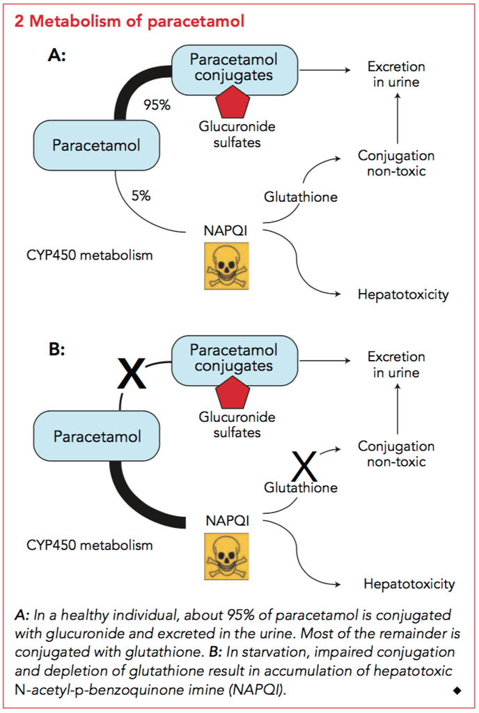

**NAC** also acts by conjugating with NAPQI to make it harmless.  
PCM is metabolized by the **CP450 system.**

#### Pharmacokinetics of paracetamol

Rapidly absorbed, peak reached by **2 hours**. Food may prolong gastric emptying and thus the time to peak.  
Elimination half life - **2 to 4 hours,**

Most patients are initially asymptomatic; but some of them can go on to develop liver injury.  
Hepatic and organ injury develops about *10 hours after ingestion* -> Antidotes must be started within 8 hours of ingestion.  
*Transaminases elevate by 24 hours*.  
If transaminases > 1000, significant risk of liver damage.

Gastric decontamination to be done if within 2 hours of ingestion.  
Methionine is an alternate antidote.  
NAC preferred if there is risk of hepatic encephalopathy; but NAC has a risk of *anaphylactoid reaction* -> due to dose related histamine releaase.  
Usually **NAC is restarted** after cessation for the reaction.

#### Therapeutic mechanism of paracetamol

[Source](https://sci-hub.se/https://doi.org/10.1111/1440-1681.13392)

- The exact mechanism of action is unclear but many studies have shown that paracetamol *somehow inhibits the synthesis of* [[General Pharmacology#Prostaglandin and COX pathway|prostaglandins]].
- This inhibition preferentially happens within the CNS. (and less in other tissues) and exerts the analgesic and antipyretic effects.
- This may explain why paracetamol **has no anti-inflammatory** and **no antiplatelet** effects, despite having similar enzyme targets as Aspirin.

[figure not shown]

- Just to show that the mechanism of action if probably complex and hasn't been determined yet.

### Mechanism of toxicity:

With toxic doses of PCM, *glutathione* which conjugates harmful NAPQI becomes depleted, leaving NAPQI (*N-acteyl P benzoquinone imine*) to inflict liver damage.  
NAPQI binds irreversibly to mitochondrial proteins.

#### Factors predisposing to toxicity

- Ovedose
- Increased CYP450 activity
- Decreased glutathione reserves
- Decreased capacity for glucuronidation or sulfation
- Increased age is a risk factors; age > 40 years -> higher risk of liver injury. Children < 5 years are less sussceptible.
- Acute alcohol injection **is not a risk factor for hepatotoxicity** in PCM overdose. This may be due to the fact that alcohol competes with acetaminophen as a substrate for the CYP450 system.

## Clinical aspects of toxicity

### Risk of toxicity based on dose

| Dose | Effect |
| --- | --- |
| 🟢 < 10g (approx. < 135 mg / Kg) | Toxicity unlikely |
| 🟡135 - 250 | Toxicity possible |
| 🟠 > 250 mg / Kg | Toxicity likely |
| 🔴🔴> 350 mg / Kg | Severe liver injury |

### Details on progression and monitoring of hepatic toxicity:

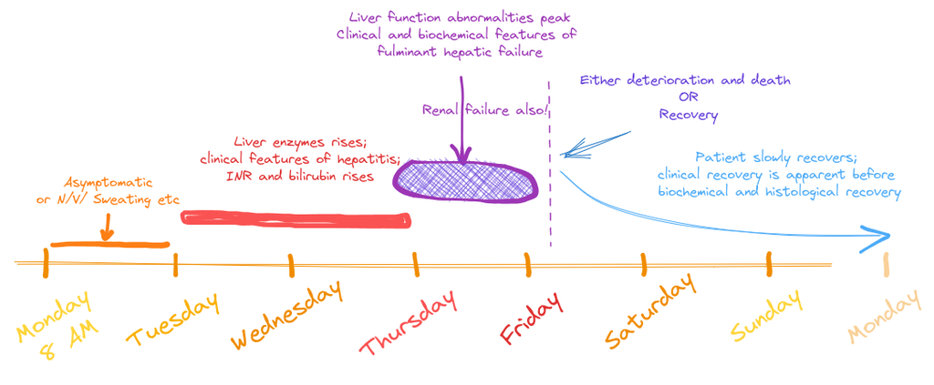

- Stage I (**1st day**) - 0.5 to 24 hours after ingestion
  - Many are asymptomatic; some have nausea, vomiting, diaphoresis, pallor,
  - AST / ALT may rise as early at 8 hours but **usually normal**
- Stage II (**day 2 and 3**) - 24 to 72 hours
  - 50% have transaminase rises by 24 hours, all have rises by 36 hours.
  - right upper quadrant pain with liver enlargement and tenderness
  - Incr. PT / INR; Incr. Total bilirubin
- Stage III (72 to 94 hours) (**day 4**)
  - liver function abnormalities peak
  - jaundice, confusion (hepatic encephalopathy), a marked elevation in hepatic enzymes, hyperammonemia, and a bleeding diathesis
  - Signs of severe hepatotoxicity include plasma ALT and AST levels that often exceed 10,000 IU/L, prolongation of the PT/INR, *hypoglycemia*, *lactic acidosis*, and a total bilirubin concentration above 4.0 mg/dL or 68 micromol/L, (**primarily indirect**)
  - **Renal failure is a frequent complication**
- Stage IV - **four days to 2 weeks**
  - *If stage III is survived,* recovery phase starts around day 4 and is complete by 7 days.
  - Laboratory values may lag behind and take several weeks to normalize.
  - Histologic changes: Centrilobular region has highest CYP2E1 concentration -> Highest NAPQI -> centrilobular necrosis.
    - Histologic recovery lags behind clinical recovery. May take upto 3 months.
  - If recovery occurs, chronic hepatic dysfunction **does not occur**. IE Acetaminophen poisoning **does not cause CLCD**.

## Management of Paracetamol poisoning

Hepatic injury / failure is rare if NAC is **started within 8 hours of igestion.**

> Although some controversy persists regarding mechanism, most toxicologists believe N-acetylcysteine prevents acetaminophen-induced hepatic injury by restoring hepatic glutathione stores.

Indications:

1. Serum PCM level above normogram after 4 hours.
2. Suspected single ingestion > 150 mg / Kg
3. Unknown time of ingestion and pcm level > 10 mcg / mL
4. history of acetaminophen ingestion and *any* evidence of liver injury

### 20 hour IV protocol

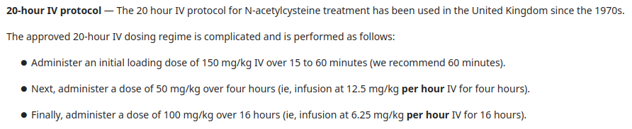

### When to stop

NAC infusion is continued according to the protocol. Some recommend that infusion is stopped based on time. If patient is not improving, Treatment can be stopped when

1. the serum [acetaminophen](https://www.uptodate.com/contents/acetaminophen-paracetamol-drug-information?search=paracetamol%20poisoning&topicRef=318&source=see_link) concentration is undetectable,
2. the ALT is clearly decreasing or in the normal range,
3. and the INR is < 2.